# S&P 500 Predictor

### Algorithms and Techniques

In this projest, we will use two regression models in supervised learning algorithms: Linear Regression and [LSTM](https://en.wikipedia.org/wiki/Long_short-term_memory). We will compare the performance of these two models and choose the better one.

### Benchmark:

## Linear Regression Model

We will create the Linear Regression model as a benchmark. Let's import the scaled data from 'data/SP500_199808_201808_scaled.csv'.

```python
import pandas as pd
import numpy as np
import time

data = pd.read_csv(filename_scale)
data.Date = pd.to_datetime(data.Date)
data.head()
```

|  | Date | Open | High | Low | Close | Volume |
| --- | --- | --- | --- | --- | --- | --- |
| 0 | 1998-08-03 | 0.201737 | 0.195867 | 0.203049 | 0.198471 | 0.033314 |
| 1 | 1998-08-04 | 0.197975 | 0.194921 | 0.185395 | 0.180113 | 0.054029 |
| 2 | 1998-08-05 | 0.179547 | 0.178880 | 0.178771 | 0.184352 | 0.053939 |
| 3 | 1998-08-06 | 0.183802 | 0.181705 | 0.186823 | 0.188086 | 0.046517 |
| 4 | 1998-08-07 | 0.187550 | 0.187027 | 0.191299 | 0.188004 | 0.045687 |

To make a simple Linear Regression model, we select two columns from data:

```
data['Date'], data['Close']
```

Since data['Date'] is in datetime format, so we create a linear array, from 0 to len(data['Date']), to represent the Date.

```python
dates = data['Date'].tolist()
y_val = np.array(data['Close'].values.tolist())
X_val = np.transpose([list(range(len(y_val)))])
```

We split the datesets into training dataset and testing dataset. The last 1000 instances are for testing, and others are for training.

And we copy the data['Date'] for ploting later.

```python
# train test split
test_data_size=1000

# train data
X_train = X_val[0: - test_data_size]
y_train = y_val[0:- test_data_size]
dates_train = dates[0:- test_data_size]

# test data
X_test = X_val[-test_data_size:]
y_test = y_val[-test_data_size:]
dates_test = dates[-test_data_size:]

print("Size of X_train", X_train.shape)
print("Size of y_train", y_train.shape)
print("Size of X_test", X_test.shape)
print("Size of y_test", y_test.shape)
```

```
Size of X_train (4033, 1)
Size of y_train (4033,)
Size of X_test (1000, 1)
Size of y_test (1000,)
```

From sklearn, we import sklearn.linear_model as our model, and fit the model on our training dataset. Then use this model to predict the targets value in the testing dataset.

```python
# Create Linear Regression Model
from sklearn import linear_model
from keras.metrics import mean_squared_error

# Linear Regression model
model = linear_model.LinearRegression()
# model fit
model.fit(X_train, y_train)
# prediction
y_train_predict = model.predict(X_train)
y_predict = model.predict(X_test)
```

Plot the fitting result on the training dataset:

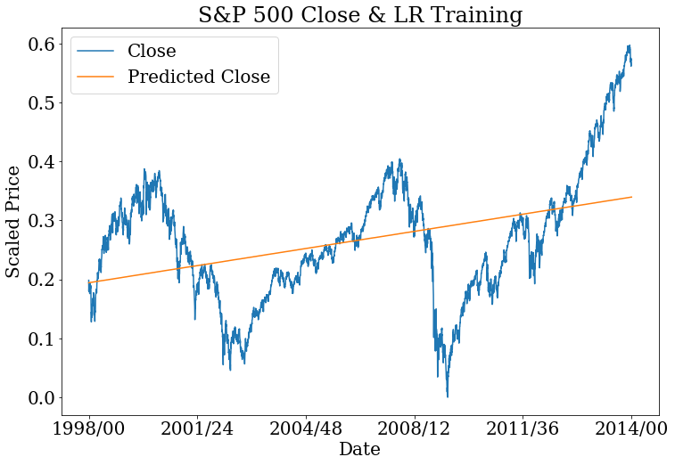

```python
import matplotlib.dates as mdates

fig, ax = plt.subplots()
ax.plot(dates_train,y_train, label='Close')
ax.plot(dates_train,y_train_predict, label='Predicted Close')
ax.legend(loc='upper left')
ax.set_title('S&P 500 Close & LR Training')
dt = (dates_train[-1] - dates_train[0])/5;
my_x_ticks = np.arange(dates_train[0], dates_train[-1]+dt, dt)
plt.xticks(my_x_ticks)
plt.gca().xaxis.set_major_formatter(mdates.DateFormatter('%Y/%M'))
plt.ylabel('Scaled Price')
plt.xlabel('Date')
plt.rc('font', family='serif', size=20)
plt.rcParams['figure.figsize'] = (12, 8)
plt.savefig("images/SP500_Close_LR_train.png")
plt.show()
```

Plot the prediction result on the testing dataset:

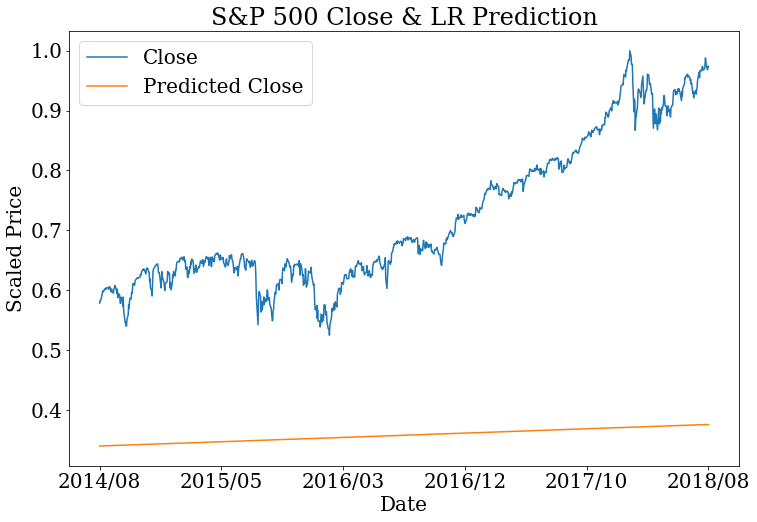

```python
# plot prediction value vs real value
import matplotlib.dates as mdates

fig, ax = plt.subplots()
ax.plot(dates_test,y_test, label='Close')
ax.plot(dates_test,y_predict, label='Predicted Close')
ax.legend(loc='upper left')
ax.set_title('S&P 500 Close & LR Prediction')
dt = (dates_test[-1] - dates_test[0])/5;
my_x_ticks = np.arange(dates_test[0], dates_test[-1]+dt, dt)
plt.xticks(my_x_ticks)
plt.gca().xaxis.set_major_formatter(mdates.DateFormatter('%Y/%m'))

plt.ylabel('Scaled Price')
plt.xlabel('Date')
plt.rc('font', family='serif', size=20)
plt.rcParams['figure.figsize'] = (12, 8)
plt.savefig("images/SP500_Close_LR_predict.png")
plt.show()
```

The prediction result is not good in the graph. We can see the RMSE performance is vary bad.

```python
# RMSE performance
RMSE_train = np.sqrt(np.mean( (y_train_predict - y_train)**2))
print('RMSE on training dataset: % 0.6f' % RMSE_train)

RMSE_test = np.sqrt(np.mean( (y_predict - y_test)**2))
print('RMSE on testing dataset: % 0.6f' % RMSE_test)
```

```
RMSE on training dataset:  0.116004
RMSE on testing dataset:  0.383239
```

```python
# Original RMSE Performance
RMSE_test_origin = RMSE_test*magnify
print('Original RMSE on testing dataset: % 0.6f' % RMSE_test_origin )
```

```
Original RMSE on testing dataset:  841.723179
```

The RMSE on the un-scaled original data is unbelievablly large, about 1/3 of the highest price value.

In conclusion, a simple linear regression is not valid in this problem.

## LSTM Model

In these Chapter, we will build a [LSTM](https://en.wikipedia.org/wiki/Long_short-term_memory) (Long Short-Term Memory) model. And then try to improve it to get a better prediction.

### Data Preprocessing

In LSTM model, the input is no longer a single instance in one day.

For each instance here, we will include the date of recent 50 days as a input, that means each input is a data matrix.

The Closing Price data['Close'] in the next day is the target.

We also copy the data['Date'] for ploting later.

```python
# Modify training and testing datasets for LSTM
days_pred=1
days_include=50

X_val = data[scale_columns].values.tolist()
y_val = data['Close'].values.tolist()
y_val = np.reshape(y_val,(len(y_val),1))

X = []
for index in range(len(X_val) - days_include):
    X.append(X_val[index: index + days_include])

y = y_val[days_include + days_pred - 1:]

dates = dates = data['Date'].tolist()
dates = dates[days_include + days_pred - 1:]

X = np.array(X)
y = np.array(y)
print('Shape of the input dataset:')
print(X.shape)
print('Shape of the output dataset:')
print(y.shape)
```

```
Shape of the input dataset:
(4983, 50, 5)
Shape of the output dataset:
(4983, 1)
```

We split the datesets into training dataset and testing dataset. The last 1000 instances are for testing, and others are for training.

```python
# train test split
test_data_size=1000

# train data
X_train = X[0:- test_data_size]
y_train = y[0:- test_data_size]
dates_train = dates[0:- test_data_size]

# test data
X_test = X[-test_data_size:]
y_test = y[-test_data_size:]
dates_test = dates[-test_data_size:]

print("Size of X_train", X_train.shape)
print("Size of y_train", y_train.shape)
print("Size of X_test", X_test.shape)
print("Size of y_test", y_test.shape)
```

```
Size of X_train (3983, 50, 5)
Size of y_train (3983, 1)
Size of X_test (1000, 50, 5)
Size of y_test (1000, 1)
```

### Implementation

Now we use keras to build a LSTM model.

Parameters:

- input_shape is based on the size of input instance
- unites is the how many days included in each input instance, here is 50
- batch_size = 100
- epochs = 5

Layers:

- Dropout(0.2)
- LSTM(128)
- Dropout(0.2)
- Dense(units = 1)
- Activation('linear')

```python
import pandas as pd
import numpy as np
import time
from keras.layers.core import Dense, Activation, Dropout
from keras.layers.recurrent import LSTM
from keras.models import Sequential
from keras.metrics import mean_squared_error

def model_lstm(in_size, units, return_sequences):

    model = Sequential()
    model.add(LSTM(
        input_shape = (None, in_size),
        units = units,
        return_sequences = return_sequences))
    model.add(Dropout(0.2))
    model.add(LSTM(128,return_sequences = False))
    model.add(Dropout(0.2))
    model.add(Dense(units = 1))
    model.add(Activation('linear'))

    return model
```

Compile the model based on the size of input instance.

```python
# LSTM model
model = model_lstm(in_size = X_train.shape[-1],units = days_include, return_sequences=True)

# Compile the model
model.compile(loss='mean_squared_error', optimizer='adam')
```

Then we train the LSTM model on our training dataset for 5 epoches.

```python
# parameters
batch_size = 100
epochs = 5

# model fit
model.fit(
    X_train,
    y_train,
    batch_size=batch_size,
    epochs=epochs,
    verbose=2,
    validation_split=0.05)
```

```
Train on 3783 samples, validate on 200 samples
 - 43s - loss: 0.0042 - val_loss: 5.8551e-04
 - 45s - loss: 6.7066e-04 - val_loss: 7.8203e-04
 - 48s - loss: 5.3625e-04 - val_loss: 2.9757e-04
 - 52s - loss: 5.0779e-04 - val_loss: 1.0400e-04
 - 49s - loss: 4.7341e-04 - val_loss: 1.8065e-04
```

```
<keras.callbacks.History at 0x1a381ee198>
```

The trained model is been saved in 'saved_model/lstm.h5'.

```python
# save model
model.save('saved_model/lstm.h5')
```

Then we check the output performance on training dataset and make a prediction on testing dataset.

```python
# Prediction
from keras.models import load_model

model = load_model('saved_model/lstm.h5')
y_train_predict = model.predict(X_train)
y_predict = model.predict(X_test)
```

Plot the fitting result on the training dataset:

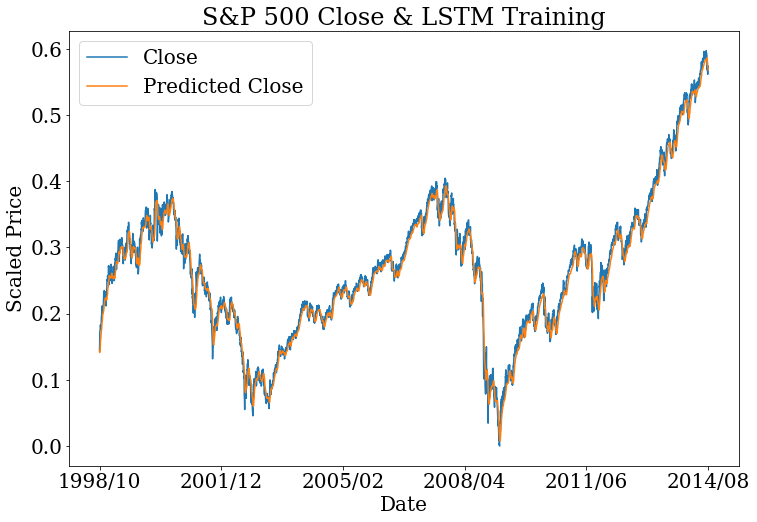

```python
import matplotlib.dates as mdates

fig, ax = plt.subplots()
ax.plot(dates_train,y_train, label='Close')
ax.plot(dates_train,y_train_predict, label='Predicted Close')
ax.legend(loc='upper left')
ax.set_title('S&P 500 Close & LSTM Training')
dt = (dates_train[-1] - dates_train[0])/5;
my_x_ticks = np.arange(dates_train[0], dates_train[-1]+dt, dt)
plt.xticks(my_x_ticks)
plt.gca().xaxis.set_major_formatter(mdates.DateFormatter('%Y/%m'))

plt.ylabel('Scaled Price')
plt.xlabel('Date')
plt.rc('font', family='serif', size=20)
plt.rcParams['figure.figsize'] = (12, 9)
plt.savefig("images/SP500_Close_LSTM_train.png")
plt.show()
```

Plot the prediction result on the testing dataset:

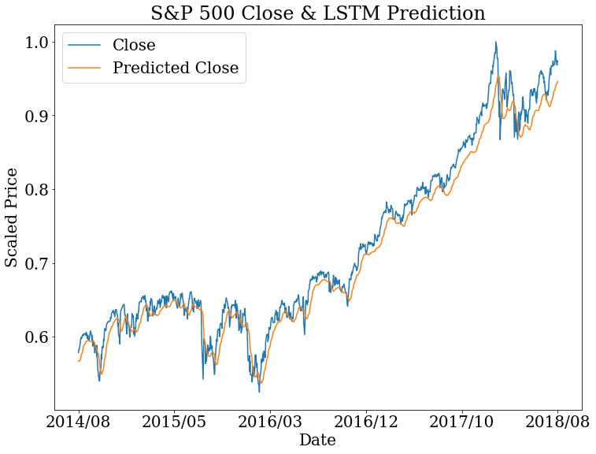

```python
import matplotlib.dates as mdates

fig, ax = plt.subplots()
ax.plot(dates_test,y_test, label='Close')
ax.plot(dates_test,y_predict, label='Predicted Close')
ax.legend(loc='upper left')
ax.set_title('S&P 500 Close & LSTM Prediction')
dt = (dates_test[-1] - dates_test[0])/5;
my_x_ticks = np.arange(dates_test[0], dates_test[-1]+dt, dt)
plt.xticks(my_x_ticks)
plt.gca().xaxis.set_major_formatter(mdates.DateFormatter('%Y/%m'))

plt.ylabel('Scaled Price')
plt.xlabel('Date')
plt.rc('font', family='serif', size=20)
plt.rcParams['figure.figsize'] = (12, 9)
plt.savefig("images/SP500_Close_LSTM_predict.png")
plt.show()
```

The prediction result is much better than the Linear Regression model.

We can see the RMSE is very small on the training dataset.

However, on the testing dataset, the RMSE is not small enough, there is a bias that most of the prediction value is less than the real value. And obviously, the model is overfitted since RMSE on testing is much larger than training.

```python
# RMSE performance
RMSE_train = np.sqrt(np.mean( (y_train_predict - y_train)**2))
print('RMSE on training dataset: % 0.6f' % RMSE_train)

RMSE_test = np.sqrt(np.mean( (y_predict - y_test)**2))
print('RMSE on testing dataset: % 0.6f' % RMSE_test)
```

```
RMSE on training dataset:  0.013485
RMSE on testing dataset:  0.021833
```

All the values above is based on the scaled data.

For the original data, the RMSE should be magnified by a factor: max(data['Close']) - min(data['Close'])

```python
# Original RMSE Performance
RMSE_test_origin = RMSE_test*magnify
print('Original RMSE on testing dataset: % 0.6f' % RMSE_test_origin )
```

```
Original RMSE on testing dataset:  47.953439
```

This is still not a good performance. It needs to be improved.

### Refinement

We supposed to refine the parameters for a better performance, but did not get a better result. There are several reasons:

- The data in the recent 1000 days is the higher than anytime in history. That's why we got a negative bias on prediction.
- The Price everyday is changed from the Open Price today or Closing Price yesterday. That means we don't need to know what the price is, we just need to know the price change everyday. And the closing price can be derived from the price change amount. Then the prediction of the Closing Price tomorrow will not be far away from that today.

## Use LSTM on Price Change

We generate another target: increasing rate everyday, and prepare the training and testing datasets as we shown in previous.

```python
change_val = y_val - np.roll(y_val, 1)
change = change_val[days_include + days_pred - 1:]
change_train = change[0:- test_data_size]
change_test = change[-test_data_size:]
```

We still applied the LSTM model in previous. The only difference is we use increasing rate as the target.

Compile the model and training the model on the training dataset.

```python
# LSTM model
model2 = model_lstm(in_size = X_train.shape[-1],units = days_include, return_sequences=True)

# Compile the model
model2.compile(loss='mean_squared_error', optimizer='adam')
```

## Result

### Model Evaluation and Validation

Based on the training result , the validation performance is much better than the previous LSTM.

```python
# parameters
batch_size = 100
epochs = 5

# model fit
model2.fit(
    X_train,
    change_train,
    batch_size=batch_size,
    epochs=epochs,
    verbose=2,
    validation_split=0.05)
```

```
Train on 3783 samples, validate on 200 samples
 - 44s - loss: 3.7539e-04 - val_loss: 1.0599e-04
 - 45s - loss: 8.6071e-05 - val_loss: 2.9931e-05
 - 47s - loss: 7.4710e-05 - val_loss: 4.7925e-05
 - 51s - loss: 6.3652e-05 - val_loss: 2.9682e-05
 - 47s - loss: 5.8748e-05 - val_loss: 3.1733e-05
```

```
<keras.callbacks.History at 0x1a3f7a5b38>
```

Save the new LSTM model into 'saved_model/lstm2.h5'

```python
# save model
model2.save('saved_model/lstm2.h5')
```

For the price change, we calculate the prediction on training dataset, and make a prediction on testing dataset.

```python
# Prediction
from keras.models import load_model

model2 = load_model('saved_model/lstm2.h5')
change_train_predict = model2.predict(X_train)
change_predict = model2.predict(X_test)
```

Then calculate the scaled price value prediction, on both training set and testing set.

```python
# calculate the new predictions based on the price change
y_pre = y_val[days_include + days_pred - 1 -1 : -1]
y_train_pre = y_pre[0:- test_data_size]
y_test_pre = y_pre[-test_data_size:]

y_train_predict2 = y_train_pre + change_train_predict
y_predict2 = y_test_pre + change_predict
```

Plot the fitting result on the training dataset:

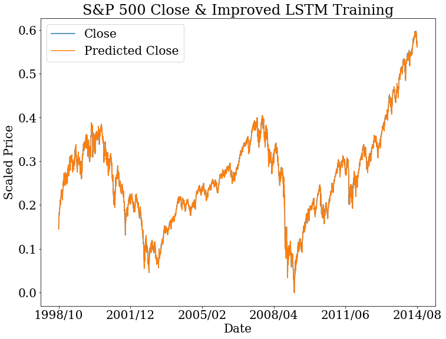

```python
import matplotlib.dates as mdates

fig, ax = plt.subplots()
ax.plot(dates_train,y_train, label='Close')
ax.plot(dates_train,y_train_predict2, label='Predicted Close')
ax.legend(loc='upper left')
ax.set_title('S&P 500 Close & Improved LSTM Training')
dt = (dates_train[-1] - dates_train[0])/5;
my_x_ticks = np.arange(dates_train[0], dates_train[-1]+dt, dt)
plt.xticks(my_x_ticks)
plt.gca().xaxis.set_major_formatter(mdates.DateFormatter('%Y/%m'))

plt.ylabel('Scaled Price')
plt.xlabel('Date')
plt.rc('font', family='serif', size=20)
plt.rcParams['figure.figsize'] = (12, 9)
plt.savefig("images/SP500_Close_LSTM2_train.png")
plt.show()
```

Plot the prediction result on the testing dataset:

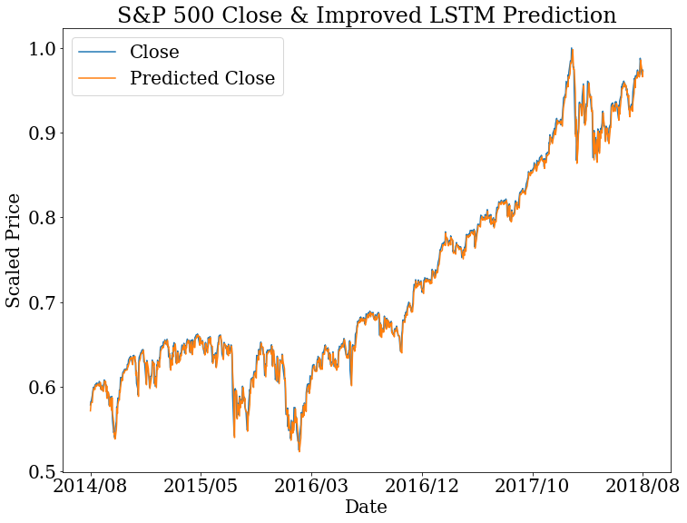

```python
import matplotlib.dates as mdates

fig, ax = plt.subplots()
ax.plot(dates_test,y_test, label='Close')
ax.plot(dates_test,y_predict2, label='Predicted Close')
ax.legend(loc='upper left')
ax.set_title('S&P 500 Close & Improved LSTM Prediction')
dt = (dates_test[-1] - dates_test[0])/5;
my_x_ticks = np.arange(dates_test[0], dates_test[-1]+dt, dt)
plt.xticks(my_x_ticks)
plt.gca().xaxis.set_major_formatter(mdates.DateFormatter('%Y/%m'))

plt.ylabel('Scaled Price')
plt.xlabel('Date')
plt.rc('font', family='serif', size=20)
plt.rcParams['figure.figsize'] = (12, 9)
plt.savefig("images/SP500_Close_LSTM2_predict.png")
plt.show()
```

```python
# RMSE performance
RMSE_train = np.sqrt(np.mean( (y_train_predict2 - y_train)**2))
print('RMSE on training dataset: % 0.6f' % RMSE_train)

RMSE_test = np.sqrt(np.mean( (y_predict2 - y_test)**2))
print('RMSE on testing dataset: % 0.6f' % RMSE_test)
```

```
RMSE on training dataset:  0.006712
RMSE on testing dataset:  0.008394
```

Now the prediction result has been improved much better.

We can find that RMSE becomes very small on both training and testing datasets.

For the un-scaled original data, the RMSE is also been decreased more than half.

```python
# Original RMSE Performance
RMSE_test_origin = RMSE_test*magnify
print('Original RMSE on testing dataset: % 0.6f' % RMSE_test_origin )
```

```
Original RMSE on testing dataset:  18.435910
```

### Justification

Compare with the benchmark result in Linear Regression model, our improved LSTM model improve the un-scaled RMSE from 841.723179 to 18.435910, decrease 97.8% RMSE.

```python
price_mean = np.mean(y_test)*magnify + price_min

print('The average closing price in the recent 1000 days is: %.6f'
      % price_mean)
```

```
The average closing price in the recent 1000 days is: 2259.413251
```

```python
error_percent_mean = RMSE_test_origin / price_mean
print('So the average percentage error, is: %.6f / %.6f = %.6f %%'
     % (RMSE_test_origin,price_mean, error_percent_mean*100) )
```

```
So the average percentage error, is: 18.435910 / 2259.413251 = 0.815960 %
```

## Conclusion

### Free-Form Visualization

We compare the percentage error for the three models, the improved LSTM model has the best performance.

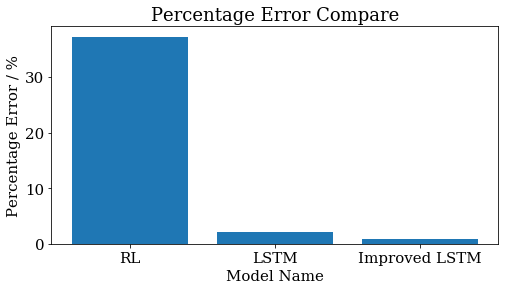

```python
import matplotlib.dates as mdates

fig, ax = plt.subplots()
error_percent_list = [841.723179,47.953439,18.435910]/price_mean*100
tick_label = ['RL','LSTM','Improved LSTM']
plt.bar([1,2,3],error_percent_list,tick_label = tick_label)
ax.set_title('Percentage Error Compare')
plt.ylabel('Percentage Error / %')
plt.xlabel('Model Name')
plt.rc('font', family='serif', size=15)
plt.rcParams['figure.figsize'] = (8, 4)
plt.savefig("images/model_compare.png")
plt.show()
```

### Reflection

- Our percentage error seems very small, but for a single day prediction, it is still unacceptable.
- If you just simply predict that the price tomorrow is the same with today, you can get a very good performance in RMSE. So this is just a toy model for machine learning practice, it cannot be used in real trading.

### Improvement

Some improvement has not been used here, but might be useful:

- More features can be find from more datasets.
  - S&P 500 index comprises about 500 stocks, pick up some stocks and include them into input.
  - Different market interact with each other. We may add some other datasets like: Index Futures, CL Price.
- Stock price is determined by human behavoir, and human behavior is based the information they access. Internet informations, such as hot news and google search trends, indicats the potential behavior of people. An ideal model should include Natural Language Processing(NLP) on internet information.
- We may not need to create the wheel from the beginning, transfer learning from another well trained model could be another choice.

```python
from IPython.display import HTML

HTML('''<script>
code_show=true;
function code_toggle() {
 if (code_show){
 $('div.input').hide();
 } else {
 $('div.input').show();
 }
 code_show = !code_show
}
$( document ).ready(code_toggle);
</script>
<form action="javascript:code_toggle()"><input type="submit" value="Click here to toggle on/off the raw code."></form>''')
```